# Propensity to Cycle Tool - local results

Created by the NPCT team

This document was produced automatically at 2015-09-14 21:51:50.

## Introduction

The results of NPCT scenarios are based on a model. This document presents information about the input data, model diagnostics, run time and information about its outputs.

The aim is to provide further information for transport planners and researchers on the origin of results presented in the NPCT’s interactive map. This document is designed for use by advanced users: some technical knowledge is needed to understand all its outputs.

The model driving the NPCT is licensed under the open source MIT License and can be modified by others provided attribution to the original.

## Initial parameters

The preset values used to select the study area and filter the flow data were as follows:

```r
# Set local authority and ttwa zone names
la # print the name of the local authority
```

```
## [1] "manchester"
```

```r
la_path <- file.path("pct-data", la)

if(!dir.exists(la_path)) dir.create(la_path) # on a unix machine

# Minimum flow between od pairs, subsetting lines. High means fewer lines.
mflow <- 30
mdist <- 15 # maximum euclidean distance (km) for subsetting lines
min_zones <- 60 # minumum number of zones in study area before buffer used
buff_dist <- 3 # buffer (km) used to select additional zones (often redundant)
```

## Input zone data

The input zones area are summarised in this section.

The characteristics of zones are as follows:

- Number of zones: 138, compared with 6791 in England
- Median area of zones: 196.9 ha, compared with 300 ha across England

## Input flow data

There are **15375** flows with origins and destinations in the study area. Of these, **2312** meet the criteria that 30 people reported travelling between these two areas in the 2011 Census (a modifiable parameter used to reduce the computational requirements of the model). That is **15.04%** of flows, accounting for **68.75%** of commutes in the study area.

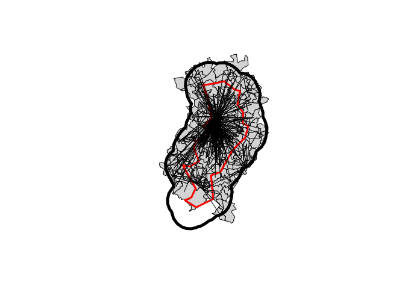

The study area (dark line), selected zones for training the model (grey) and the administrative zone of interest (red line). The black straight lines represent the most intensive commuting flows.

## Hilliness of flows

The average hilliness of zones in the study area is 1.28 degrees, compared with the national average of 2.25. This data is displayed in the figure below.

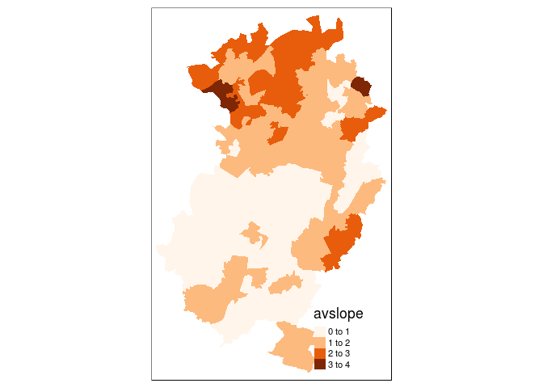

## Lines allocated to the road network

We use CycleStreets.net to estimate optimal routes. An illustration of these routes is presented below.

```
## [1] TRUE
```

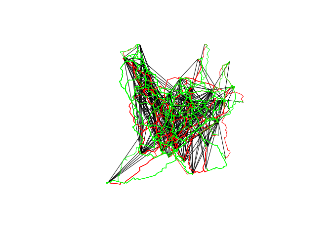

Sample of the straight and route-lines allocated to the travel network

```
## [1] "Warning, lines and routes are different lengths"
```

## Distance distributions

The distance distribution of trips in the study area is displayed in the figure below, which compares the result with the distribution of trips nationwide.

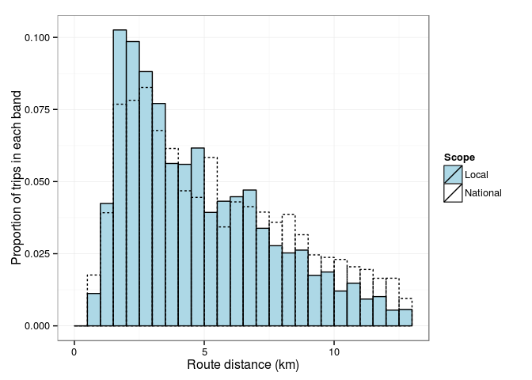

Distance distribution of all trips in study lines (blue) compared with national average (dotted bars)

From the nationwide sample of trips, 51.5% of trips are less than 5km.

In the case study area 59.38% of sampled trips are less than 5km.

Subsetting by distance (set to 15 km) and removing inter-zone flows further reduces the number of flows from 2312 to 2169.

## The flow model

To estimate the potential rate of cycling under different scenarios regression models operating at the flow level are used. These can be seen in the model script which is available [online](https://github.com/npct/pct/blob/master/models/aggregate-model.R).

## Cycling in the study area

The overall rate of cycling in the flows in the study area (after subsetting for distance) is 4.6%, compared a rate from the national data (of equally short flows) of 5.0%.

## Scenarios

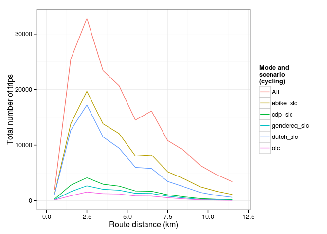

| dist_band | All | olc | ebike_slc | cdp_slc | gendereq_slc | dutch_slc |
| --- | --- | --- | --- | --- | --- | --- |
| (0,2] | 15.7 | 3.63 | 54.7 | 11.19 | 6.57 | 50.29 |
| (2,5] | 43.7 | 5.22 | 59.31 | 12.62 | 8.56 | 49.61 |
| (5,10] | 32.4 | 4.72 | 49.15 | 9.84 | 7.28 | 33.8 |
| (10,20] | 8.2 | 2.36 | 30.61 | 4.9 | 3.44 | 16.09 |
| Total | 100.0 | 4.57 | 52.93 | 10.86 | 7.41 | 41.84 |

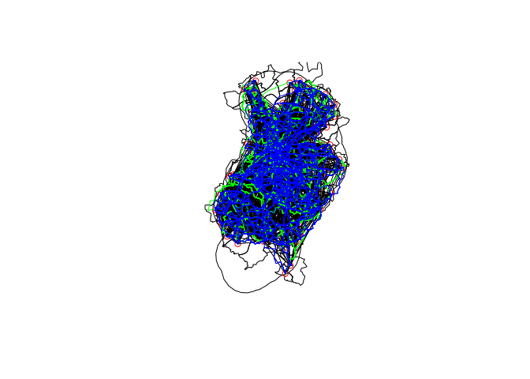

Illustration of flows on travel network

## Flow model results

To estimate the potential rate of cycling under different scenarios regression models operating at the flow level are used. These can be seen in the model script which is available [online](https://github.com/npct/pct/blob/master/models/aggregate-model.R).

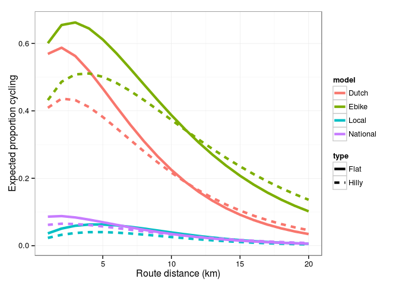

National vs local cycling characteristics with hilliness, captured in the model results

The correlation between fitted and observed cycling in the model is 0.42, compared with 0.39 nationally.

The values for the coefficients are presented in the table below.

| Model | (Intercept) | dist_fast | I(dist_fast^0.5) | avslope | dist_fast:avslope |
| --- | --- | --- | --- | --- | --- |
| National | -2.152 | -0.332 | 0.692 | -0.724 | 0.065 |
| Local | -3.802 | -0.441 | 1.846 | -0.917 | 0.006 |

## Time taken

The time taken to run the analysis for this area is presented below.

```r
end_time <- Sys.time()

end_time - start_time
```

```
## Time difference of 2.817533 mins
```